# Project02

```r
summary(newdata.validate$`Action Taken`)
```

```
## Approved   Denied
##      629       85
```

```r
model <- glm(`Action Taken` ~., data = newdata.train, family = "binomial")

summary(model)
```

```
##
## Call:
## glm(formula = `Action Taken` ~ ., family = "binomial", data = newdata.train)
##
## Deviance Residuals:
##     Min       1Q   Median       3Q      Max
## -3.1235  -0.4745  -0.3715  -0.2774   2.9177
##
## Coefficients:
##                          Estimate Std. Error z value Pr(>|z|)
## (Intercept)            -2.371e+00  5.724e-01  -4.142 3.44e-05 ***
## `Applicant Race`White  -1.382e+00  1.850e-01  -7.468 8.16e-14 ***
## `Applicant Income`      1.460e-06  1.570e-06   0.930 0.352509
## `Marital Status`S       3.055e-01  4.561e-01   0.670 0.502944
## `Marital Status`U       5.698e-01  1.725e-01   3.303 0.000958 ***
## `Self-Employed`Yes      5.754e-01  2.457e-01   2.342 0.019198 *
## `Debt to Income Ratio`  7.171e-02  9.659e-03   7.424 1.14e-13 ***
## `Years of Education`   -9.841e-02  3.147e-02  -3.127 0.001766 **
## ---
## Signif. codes:  0 '***' 0.001 '**' 0.01 '*' 0.05 '.' 0.1 ' ' 1
##
## (Dispersion parameter for binomial family taken to be 1)
##
##     Null deviance: 1193.0  on 1626  degrees of freedom
## Residual deviance: 1013.6  on 1619  degrees of freedom
##   (39 observations deleted due to missingness)
## AIC: 1029.6
##
## Number of Fisher Scoring iterations: 5
```

Original model set at 0.5

```r
prob <- predict(model, newdata.validate, type = 'response')

model.pred <- factor(prob > 0.5, levels = c(FALSE,TRUE),
                     labels = c("Approved","Denied"))

model.perf <- table(newdata.validate$`Action Taken`, model.pred, dnn = c("Actual","Predicted"))

model.perf
```

```
##           Predicted
## Actual     Approved Denied
##   Approved      609      8
##   Denied         75      5
```

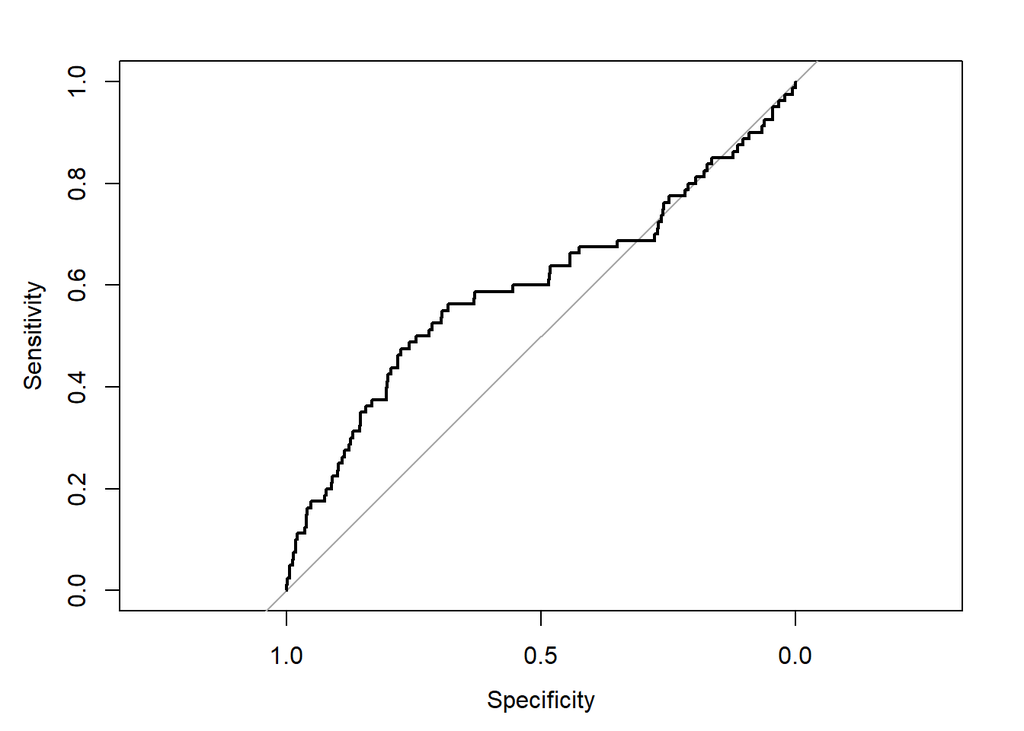

```r
my_roc <- roc(newdata.validate$`Action Taken` ~ prob, plot = TRUE)
```

```r
my_auc <- auc(my_roc)
```

Adjusted model using the threshold value

```r
threshold <- my_roc$thresholds[which.max(my_roc$sensitivities + my_roc$specificities)]

model.pred.thresh <- factor(prob > threshold, levels = c(FALSE,TRUE),
                     labels = c("Approved","Denied"))

model.perf.thresh <- table(newdata.validate$`Action Taken`, model.pred.thresh,
                     dnn = c("Actual","Predicted"))

model.perf.thresh
```

```
##           Predicted
## Actual     Approved Denied
##   Approved      478    139
##   Denied         42     38
```

When the threshold was put at 0.5, the model produced a really good number of true approvals, but also yielded 75 false positives (approvals). The threshold taken from the ROC curve was used and produced many more false negatives (predicting denied when actually approved), but limited the false positives (predicting approved when actually denied), reducing them from 75 to 42. Similar to our breast cancer example from class, I think we would prefer the higher number of false negatives rather than false positives, which give applicants unwarranted hope.

Classical Decision Tree

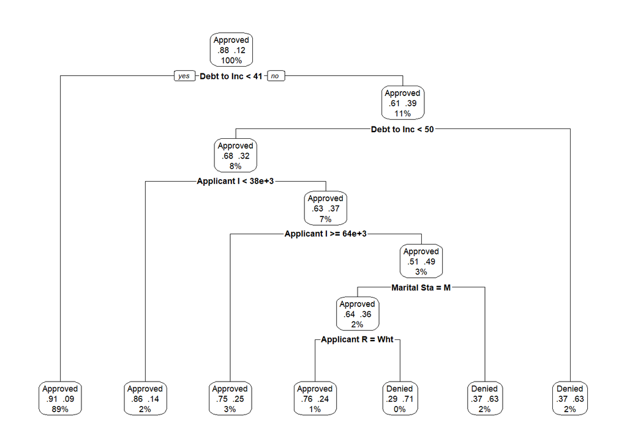

```r
set.seed(1234)

dtree <- rpart(`Action Taken` ~., data = newdata.train, method = 'class', parms = list(split = 'information'))

prp(dtree, type = 2, extra = 104,fallen.leaves = T)
```

```r
dtree.pred <- predict(dtree, newdata.validate,type = "class")

dtree.perf <- table(newdata.validate$`Action Taken`, dtree.pred, dnn = c("Actual","Predicted"))

dtree.perf
```

```
##           Predicted
## Actual     Approved Denied
##   Approved      614     15
##   Denied         77      8
```

The classical decision tree model is very similar to the original model. It produced a high number of actual approvals, but also had 77 false approvals.

Pruned Decision Tree

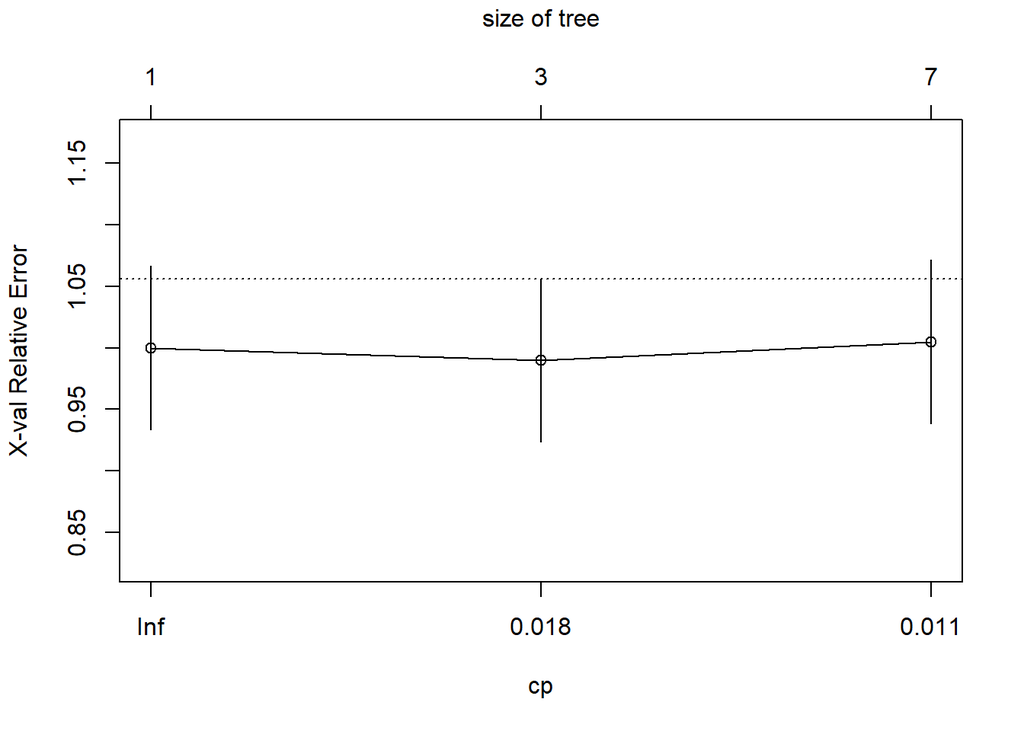

```r
plotcp(dtree)
```

```r
dtree$cptable
```

```
##           CP nsplit rel error xerror       xstd
## 1 0.02750000      0     1.000  1.000 0.06633069
## 2 0.01166667      2     0.945  0.990 0.06604320
## 3 0.01000000      6     0.895  1.005 0.06647362
```

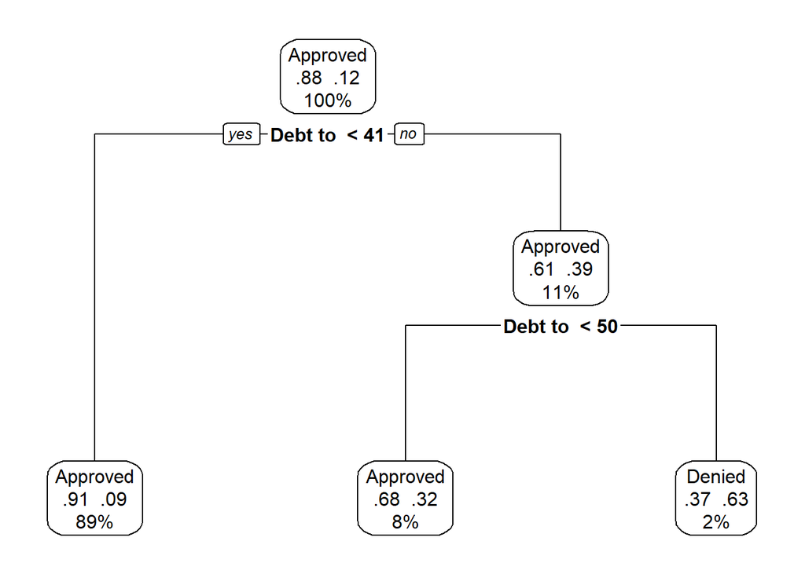

```r
dtree.pruned <- prune(dtree,cp = 0.018)

prp(dtree.pruned, type = 2, extra = 104,fallen.leaves = T)
```

```r
dtree.pruned.pred <- predict(dtree.pruned, newdata.validate,type = "class")

dtree.pruned.perf <- table(newdata.validate$`Action Taken`, dtree.pruned.pred, dnn = c("Actual","Predicted"))

dtree.pruned.perf
```

```
##           Predicted
## Actual     Approved Denied
##   Approved      620      9
##   Denied         82      3
```

Once again with the pruned decision tree, 3 out of the 4 sections were accurate, especially true approvals were the highest they have been (620). However, the false approvals were also at a high compared to other models with 82. As we discussed earlier, we are looking for a model that reducing false approvals in order to limit giving applicants unwarranted confidence in the mortgage process. The small increase in accurate approvals is probably not enough to use this model as the best one.

Support Vector Machine

```r
set.seed(1234)

fit.svm <- svm(`Action Taken` ~., data=newdata.train)

fit.svm
```

```
##
## Call:
## svm(formula = `Action Taken` ~ ., data = newdata.train)
##
##
## Parameters:
##    SVM-Type:  C-classification
##  SVM-Kernel:  radial
##        cost:  1
##
## Number of Support Vectors:  489
```

```r
svm.pred <- predict(fit.svm,na.omit(newdata.validate))

svm.perf <- table(na.omit(newdata.validate)$`Action Taken`, svm.pred, dnn = c("Actual","Predicted"))

svm.perf
```

```
##           Predicted
## Actual     Approved Denied
##   Approved      617      0
##   Denied         77      3
```

The support vector machine produced an almost equivalent number of false approvals, but it also resulted in 0 false denials which is a definite improvement compared to the other models tested.

While evaluating the different models, it is apparent that the inaccurate predicted approvals is something that will always be there. Therefore, I would select the SVM model as it has the second highest actual approvals and also brought the false denials to zero.

```r
set.seed(1234)

fit.svm.full <- svm(`Action Taken` ~., data=newdata)

fit.svm.full
```

```
##
## Call:
## svm(formula = `Action Taken` ~ ., data = newdata)
##
##
## Parameters:
##    SVM-Type:  C-classification
##  SVM-Kernel:  radial
##        cost:  1
##
## Number of Support Vectors:  741
```

```r
svm.pred.full <- predict(fit.svm.full,na.omit(newdata))

svm.perf.full <- table(na.omit(newdata)$`Action Taken`, svm.pred.full, dnn = c("Actual","Predicted"))

svm.perf.full
```

```
##           Predicted
## Actual     Approved Denied
##   Approved     2047      2
##   Denied        261     14
```

```r
#my_roc.full <- roc(newdata$`Action Taken` ~ svm.pred.full, plot = TRUE)

#my_auc.full <- auc(my_roc.full)

#Tried all different variations but could not get the ROC curve to work for this model.
```

Report:

```r
model.perf
```

```
##           Predicted
## Actual     Approved Denied
##   Approved      609      8
##   Denied         75      5
```

```r
model.perf.thresh
```

```
##           Predicted
## Actual     Approved Denied
##   Approved      478    139
##   Denied         42     38
```

```r
dtree.perf
```

```
##           Predicted
## Actual     Approved Denied
##   Approved      614     15
##   Denied         77      8
```

```r
dtree.pruned.perf
```

```
##           Predicted
## Actual     Approved Denied
##   Approved      620      9
##   Denied         82      3
```

```r
svm.perf
```

```
##           Predicted
## Actual     Approved Denied
##   Approved      617      0
##   Denied         77      3
```

```r
svm.perf.full
```

```
##           Predicted
## Actual     Approved Denied
##   Approved     2047      2
##   Denied        261     14
```